# tse_eda

Galileu Kim

May 14, 2018

Let’s start taking a look at the coalitions formed in Brazil. Focus on the local level.

[output not shown]

[output not shown]

# Number of mayor candidates per election:

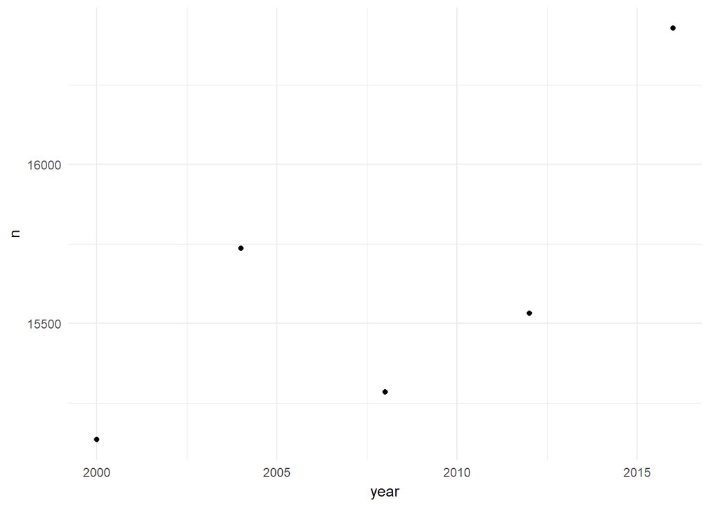

There are on average 3 candidates per municipality. There is, however, a significant spike in the year 2016 (not sure why). Of course that masks heterogeneity. Let’s visualize it:

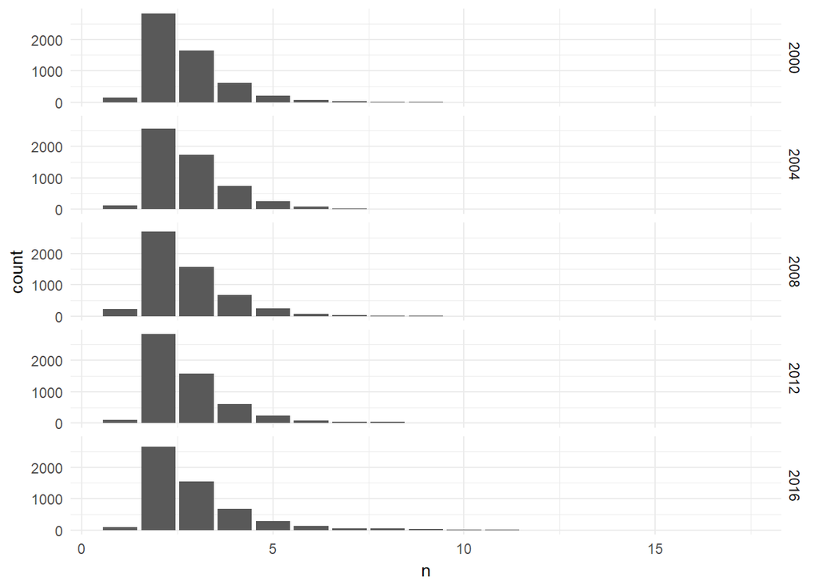

Actually, what is the distribution of sizes of these coalitions? I also need to check that.

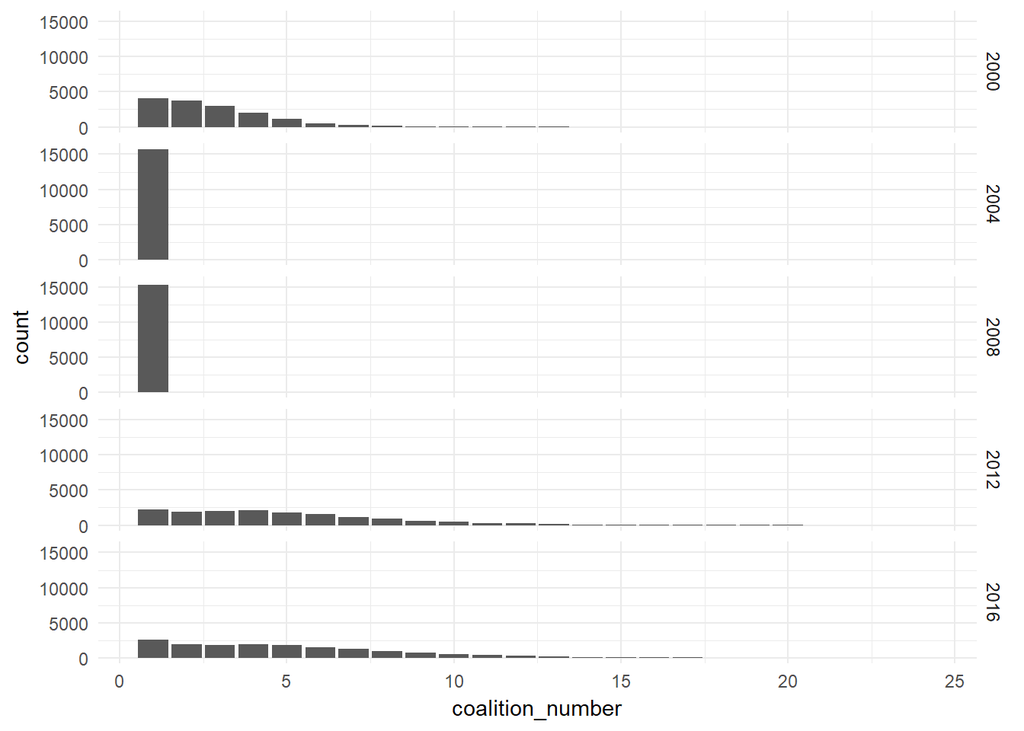

# Winning coalitions:

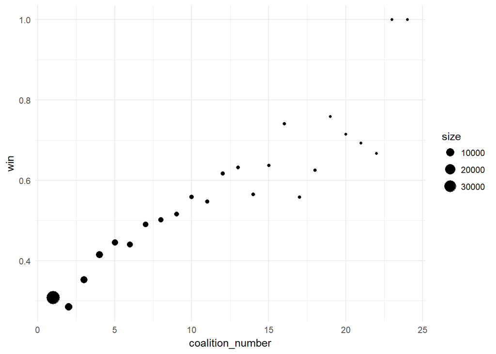

# What are the central parties?

Let’s do a simple exercise. Count the number of occurrences by party in a coalition.

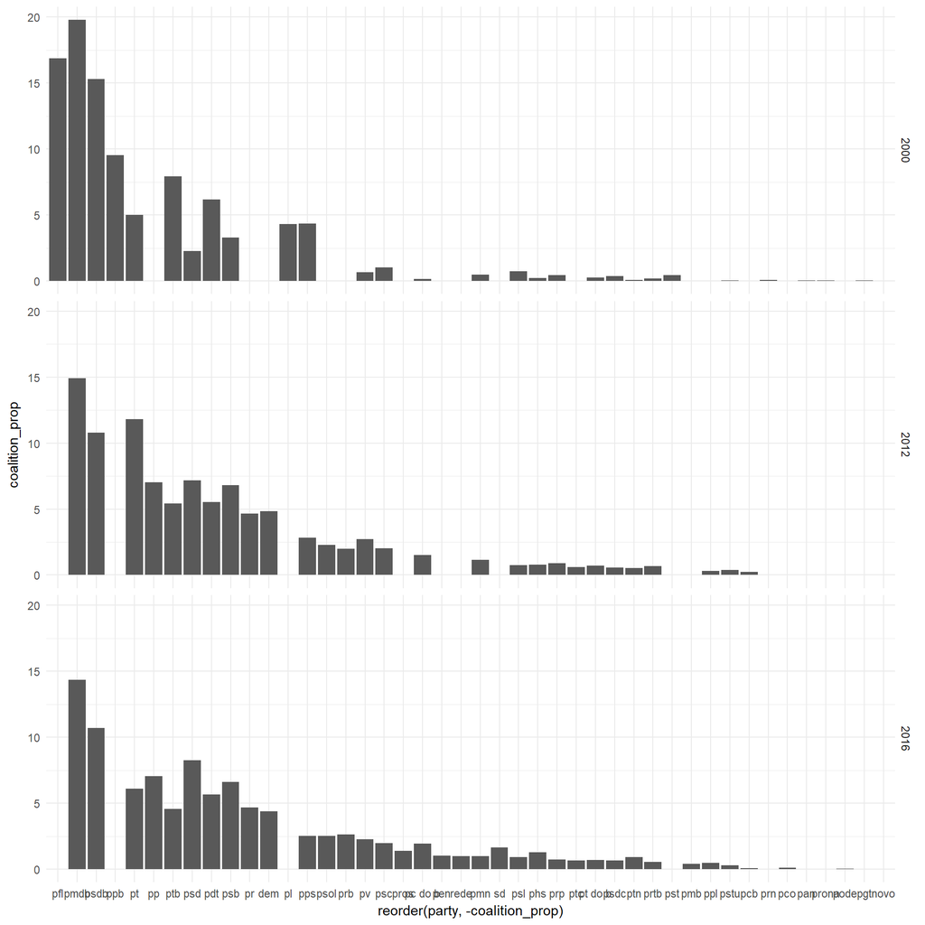

# Candidates and campaigns:

It should not be surprising that coalitions are better able to provide mayor candidates with money. Let’s check this hypothesis.

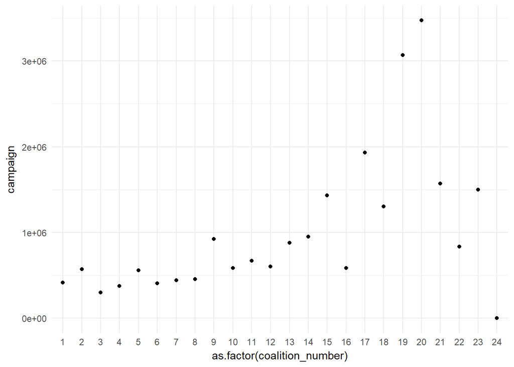

There seems to be some evidence that campaign expenditures are increasing with the size of the coalition. There seems to be, however, some strange outliers. Could be explained by a large proportion of missing values. Let’s check.

[figure not shown]

It is clear that there are missing values, especially for the years of 2000 and 2008. I wonder why that is the case. I cannot use this campaign data as is. I have to look into the *bens de candidatos* dataset later.

# Mayor characteristics:

Let’s check the educational background of mayors. I suspect there is wide heterogeneity here, as contrasted with Dal Bo et al. (2017) study on Swedish politicians.

```
##    edu            edu_desc
## 1    0       nao informado
## 2    1          analfabeto
## 3    2        le e escreve
## 4    3  1º grau incompleto
## 5    4    1º grau completo
## 6    5  2º grau incompleto
## 7    6    2º grau completo
## 8    7 superior incompleto
## 9    8   superior completo
## 10  NA                <NA>
```

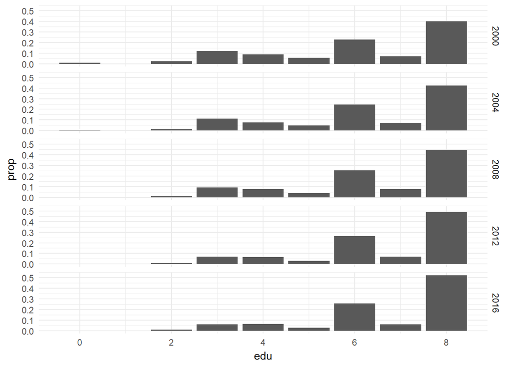

# Hierarchical mobility:

In Ferraz and Finan (2010), the hypothesis that mayors move across positions is basically discarded, with the authors pointing out that around 10% of mayors moved across positions. Let’s check this with our expanded dataset.

What are the positions available?

```
##    position_code            position
## 1              1          presidente
## 2              2     vice-presidente
## 3              3          governador
## 4              4     vice-governador
## 5              5             senador
## 6              6    deputado federal
## 7              7   deputado estadual
## 8              8  deputado distrital
## 9              9 1º suplente senador
## 10            10 2º suplente senador
## 11            11            prefeito
## 12            12       vice-prefeito
## 13            13            vereador
```

Let’s see, first, how many politicians run for multiple offices. If most are one-shots, the question becomes uninteresting. Let’s take a closer look.

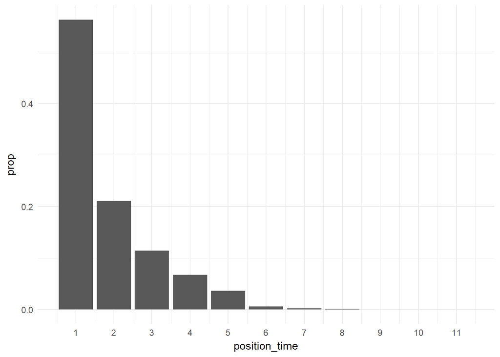

Interesting. It seems like roughly half of politicians are one-shots. This leaves us with another half who run for offices several times. Let’s isolate mayors for now.

```
## [1] 53407
```

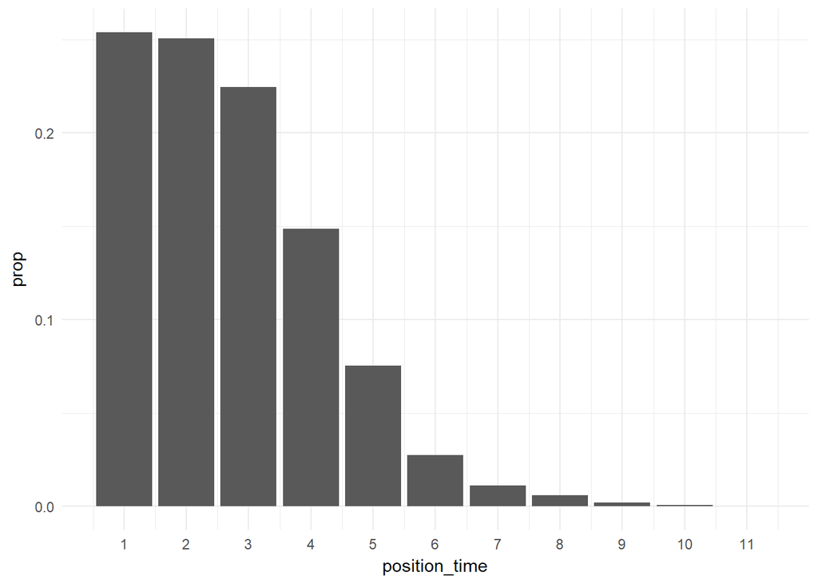

```
## # A tibble: 1 x 3
##   reelect previous_mayor percent
##     <dbl>          <int>   <dbl>
## 1   10974          27612   0.397
```

Around 11 thousand mayors run for re-election, a significant chunk of those individuals who have held a mayoral office (roughly 40%). Does the size of coalition affect probability of a re-election? What about the probability of promotion?

```
##
## Call:
## lm(formula = reelect_mayor ~ coalition_number_previous + edu +
##     gender + campaign, data = candidate_mayor)
##
## Residuals:
##     Min      1Q  Median      3Q     Max
## -0.6098 -0.2840 -0.2513  0.6508  0.8493
##
## Coefficients:
##                             Estimate Std. Error t value Pr(>|t|)
## (Intercept)                3.068e-01  1.171e-02  26.194  < 2e-16 ***
## coalition_number_previous  1.631e-02  8.272e-04  19.712  < 2e-16 ***
## edu                       -4.900e-03  1.305e-03  -3.754 0.000174 ***
## gender                    -2.116e-02  3.892e-03  -5.437 5.46e-08 ***
## campaign                  -2.595e-10  1.457e-10  -1.781 0.074944 .
## ---
## Signif. codes:  0 '***' 0.001 '**' 0.01 '*' 0.05 '.' 0.1 ' ' 1
##
## Residual standard error: 0.4469 on 39109 degrees of freedom
##   (53407 observations deleted due to missingness)
## Multiple R-squared:  0.01086,    Adjusted R-squared:  0.01076
## F-statistic: 107.4 on 4 and 39109 DF,  p-value: < 2.2e-16
```

```
##
## Call:
## lm(formula = promotion ~ coalition_number_previous + edu + gender +
##     campaign, data = candidate_mayor)
##
## Residuals:
##      Min       1Q   Median       3Q      Max
## -1.83144 -0.17734 -0.14591 -0.08848  1.01120
##
## Coefficients:
##                             Estimate Std. Error t value Pr(>|t|)
## (Intercept)                7.622e-03  9.829e-03   0.776   0.4380
## coalition_number_previous  4.470e-03  6.871e-04   6.505 7.87e-11 ***
## edu                        2.201e-02  1.099e-03  20.025  < 2e-16 ***
## gender                    -5.824e-03  3.241e-03  -1.797   0.0724 .
## campaign                   5.502e-10  1.168e-10   4.709 2.49e-06 ***
## ---
## Signif. codes:  0 '***' 0.001 '**' 0.01 '*' 0.05 '.' 0.1 ' ' 1
##
## Residual standard error: 0.3583 on 35930 degrees of freedom
##   (56586 observations deleted due to missingness)
## Multiple R-squared:  0.01357,    Adjusted R-squared:  0.01346
## F-statistic: 123.6 on 4 and 35930 DF,  p-value: < 2.2e-16
```

The results of these simple models provide some evidence that the size of the coalition improves the chances of re-election and promotion. But the effect size is quite small, especially for promotion. There must be another explanation.

# Idea: hierarchical overlap?

What if it is not the size of the coalition, but whether or not you formed the “right” kinds of alliances in lower tiers of government so as to ensure a position higher up? I would imagine that if a mayor formed coalition with the coalitions that are ruling the state, there is a higher probability of promotion.

```
##
## Call:
## lm(formula = promotion ~ as.factor(governor_alignment), data = candidate_mayor)
##
## Residuals:
##     Min      1Q  Median      3Q     Max
## -0.2920 -0.2920 -0.2920  0.7080  0.7251
##
## Coefficients:
##                                 Estimate Std. Error t value Pr(>|t|)
## (Intercept)                     0.292031   0.002975  98.146   <2e-16 ***
## as.factor(governor_alignment)1 -0.017152   0.007650  -2.242    0.025 *
## ---
## Signif. codes:  0 '***' 0.001 '**' 0.01 '*' 0.05 '.' 0.1 ' ' 1
##
## Residual standard error: 0.4535 on 27365 degrees of freedom
##   (65154 observations deleted due to missingness)
## Multiple R-squared:  0.0001837,  Adjusted R-squared:  0.0001471
## F-statistic: 5.027 on 1 and 27365 DF,  p-value: 0.02497
```

Strangely, there does not seem to be much evidence supporting this claim. I wonder why. Let’s check this for reelecting candidates.

```
##
## Call:
## lm(formula = reelect_mayor ~ as.factor(governor_alignment), data = candidate_mayor %>%
##     filter(position_previous == 11 & outcome_previous == "eleito"))
##
## Residuals:
##      Min       1Q   Median       3Q      Max
## -0.94482  0.06633  0.06633  0.06633  0.06633
##
## Coefficients:
##                                Estimate Std. Error t value Pr(>|t|)
## (Intercept)                    0.933671   0.003299 283.041   <2e-16 ***
## as.factor(governor_alignment)1 0.011145   0.007824   1.424    0.154
## ---
## Signif. codes:  0 '***' 0.001 '**' 0.01 '*' 0.05 '.' 0.1 ' ' 1
##
## Residual standard error: 0.2454 on 6727 degrees of freedom
##   (5739 observations deleted due to missingness)
## Multiple R-squared:  0.0003015,  Adjusted R-squared:  0.0001529
## F-statistic: 2.029 on 1 and 6727 DF,  p-value: 0.1544
```

There seems to be no evidence that being aligned with the governor favors the chance of re-election either. But still I am interested in the idea of a promotion.

```
##
## Call:
## lm(formula = promotion ~ governor_alignment + edu + age + gender +
##     coalition_number + as.factor(party), data = .)
##
## Residuals:
##      Min       1Q   Median       3Q      Max
## -0.53410 -0.08324 -0.05809 -0.02681  1.02547
##
## Coefficients:
##                           Estimate Std. Error t value Pr(>|t|)
## (Intercept)              0.0043714  0.0375506   0.116  0.90733
## governor_alignment       0.0003315  0.0127982   0.026  0.97933
## edu                      0.0112154  0.0024262   4.623 3.93e-06 ***
## age                     -0.0010099  0.0004609  -2.191  0.02849 *
## gender                   0.0110980  0.0083902   1.323  0.18602
## coalition_number        -0.0037551  0.0012552  -2.992  0.00280 **
## as.factor(party)pc do b  0.0685283  0.0592009   1.158  0.24713
## as.factor(party)pdt      0.0440314  0.0239587   1.838  0.06618 .
## as.factor(party)pfl      0.0371904  0.0273434   1.360  0.17388
## as.factor(party)phs     -0.0464032  0.0778186  -0.596  0.55102
## as.factor(party)pl       0.1281822  0.0397491   3.225  0.00127 **
## as.factor(party)pmdb     0.0185431  0.0192335   0.964  0.33506
## as.factor(party)pmn      0.0726007  0.0590898   1.229  0.21929
## as.factor(party)pp      -0.0044930  0.0216007  -0.208  0.83524
## as.factor(party)ppl      0.1788968  0.1088654   1.643  0.10042
## as.factor(party)pps      0.0621226  0.0297587   2.088  0.03691 *
## as.factor(party)pr       0.0455043  0.0242651   1.875  0.06084 .
## as.factor(party)prb      0.0644895  0.0477386   1.351  0.17682
## as.factor(party)prp     -0.0214942  0.0866657  -0.248  0.80414
## as.factor(party)prtb     0.1307137  0.0997236   1.311  0.19003
## as.factor(party)psb      0.0493319  0.0250629   1.968  0.04911 *
## as.factor(party)psc      0.1245846  0.0564315   2.208  0.02733 *
## as.factor(party)psd     -0.0234468  0.0266589  -0.880  0.37919
## as.factor(party)psdb     0.0136357  0.0208596   0.654  0.51336
## as.factor(party)psdc     0.4700389  0.1707197   2.753  0.00593 **
## as.factor(party)psl     -0.0355049  0.0778309  -0.456  0.64829
## as.factor(party)pt       0.0684184  0.0222382   3.077  0.00211 **
## as.factor(party)pt do b -0.0294069  0.1087959  -0.270  0.78695
## as.factor(party)ptb      0.0086319  0.0233752   0.369  0.71194
## as.factor(party)ptc     -0.0360589  0.0778291  -0.463  0.64317
## as.factor(party)ptn     -0.0340925  0.1087442  -0.314  0.75391
## as.factor(party)pv       0.0551218  0.0416918   1.322  0.18622
## ---
## Signif. codes:  0 '***' 0.001 '**' 0.01 '*' 0.05 '.' 0.1 ' ' 1
##
## Residual standard error: 0.2402 on 3372 degrees of freedom
##   (2293 observations deleted due to missingness)
## Multiple R-squared:  0.02976,    Adjusted R-squared:  0.02084
## F-statistic: 3.336 on 31 and 3372 DF,  p-value: 1.509e-09
```

# Former mayor?

There are around 57 thousand politicians who run for mayor. Does becoming a mayor help strt a political career?

```
## Observations: 57,219
## Variables: 5
## $ candidate_name <chr> "paulo cesar ferreira de araujo", "sebastiao bo...
## $ cpf            <chr> "07857136204", "17357152987", "09139583287", "1...
## $ birthyear      <chr> "1957", "1953", "1962", "1968", "1959", "1947",...
## $ elec_title     <chr> "000525772445", "002053882488", "000139702402",...
## $ mun_birth_name <chr> "vicosa", "bela vista do paraiso", "rio branco"...
```

```
##
## Call:
## lm(formula = position_time ~ reelect_mayor, data = .)
##
## Residuals:
##     Min      1Q  Median      3Q     Max
## -1.6568 -1.6568 -0.6568  0.8625  8.3432
##
## Coefficients:
##               Estimate Std. Error t value Pr(>|t|)
## (Intercept)   2.656848   0.005296  501.71   <2e-16 ***
## reelect_mayor 0.480659   0.015376   31.26   <2e-16 ***
## ---
## Signif. codes:  0 '***' 0.001 '**' 0.01 '*' 0.05 '.' 0.1 ' ' 1
##
## Residual standard error: 1.512 on 92519 degrees of freedom
## Multiple R-squared:  0.01045,    Adjusted R-squared:  0.01044
## F-statistic: 977.2 on 1 and 92519 DF,  p-value: < 2.2e-16
```

It seems to be the case. Of course the $R^2$ is quite low. Maybe we can visualize this better?

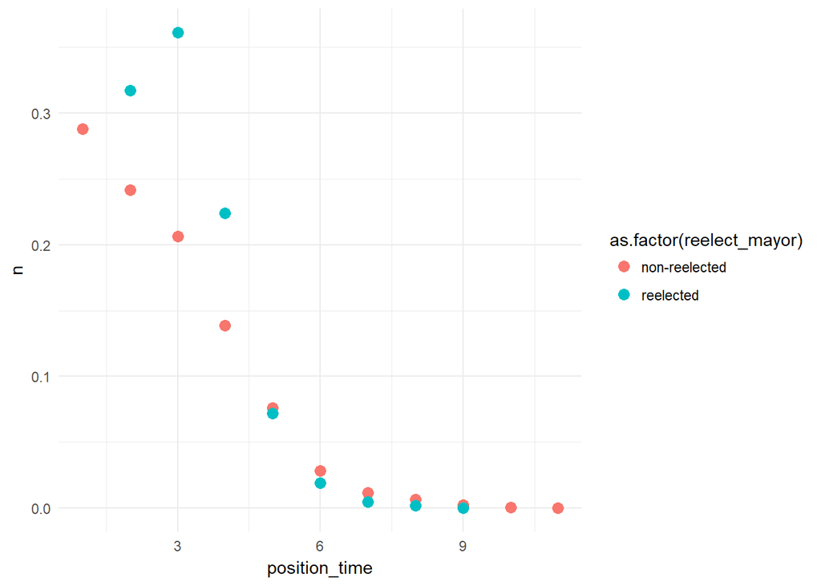

This is OK, but it is not particularly interesting. Let’s move on to my original idea about coalitions and patronage.